# Project 1 LDA Prova

Daniele Capelli

2025-10-22

# Exploratory Data Analysis in R

Start by analyzing data…

```r
library(haven)
library(sas7bdat)
library(ggplot2)
library(tidyr)
library(dplyr)
library(GGally)
library(corrplot)
alz <- read_sas("C:/Users/Daniele/Desktop/2025 - 26 Primo Semestre/Longitudinal Data Analysis/Project 1 Alzheimer LDA/alzheimer25.sas7bdat")
#alz <- read.csv("C:/Users/Daniele/Desktop/2025 - 26 Primo Semestre/Longitudinal Data Analysis/Project 1 Alzheimer LDA/alzheimer25.csv")

head(alz)
```

```
## # A tibble: 6 × 38
##   patid trial   sex   age   edu   bmi inkomen   job   adl   wzc cdrsb0 cdrsb1
##   <dbl> <dbl> <dbl> <dbl> <dbl> <dbl>   <dbl> <dbl> <dbl> <dbl>  <dbl>  <dbl>
## 1 10001     1     0    72     3  26.4    1900     0     6     0      4      1
## 2 10002     1     0    74     3  27.1    1900     0     5     0      1      3
## 3 10003     1     0    74     1  27.3    1000     0     6     0      2      1
## 4 10004     1     1    75     3  24.8    2500     0     5     1      1      3
## 5 10005     1     1    71     2  28.2    2000     0     6     1     19     11
## 6 10006     1     1    72     3  27.1    2300     0     6     1      1      2
## # ℹ 26 more variables: cdrsb2 <dbl>, cdrsb3 <dbl>, cdrsb4 <dbl>, cdrsb5 <dbl>,
## #   cdrsb6 <dbl>, bprs0 <dbl>, bprs1 <dbl>, bprs2 <dbl>, bprs3 <dbl>,
## #   bprs4 <dbl>, bprs5 <dbl>, bprs6 <dbl>, abpet0 <dbl>, abpet1 <dbl>,
## #   abpet2 <dbl>, abpet3 <dbl>, abpet4 <dbl>, abpet5 <dbl>, abpet6 <dbl>,
## #   taupet0 <dbl>, taupet1 <dbl>, taupet2 <dbl>, taupet3 <dbl>, taupet4 <dbl>,
## #   taupet5 <dbl>, taupet6 <dbl>
```

```r
summary(alz)
```

```
##      patid            trial            sex              age
##  Min.   : 10001   Min.   : 1.00   Min.   :0.0000   Min.   :46.00
##  1st Qu.: 60072   1st Qu.: 6.00   1st Qu.:0.0000   1st Qu.:67.00
##  Median :120042   Median :12.00   Median :1.0000   Median :72.00
##  Mean   :129161   Mean   :12.91   Mean   :0.5084   Mean   :72.45
##  3rd Qu.:190067   3rd Qu.:19.00   3rd Qu.:1.0000   3rd Qu.:77.00
##  Max.   :250049   Max.   :25.00   Max.   :1.0000   Max.   :94.00
##
##       edu             bmi           inkomen          job
##  Min.   :1.000   Min.   :19.80   Min.   :1000   Min.   :0.000
##  1st Qu.:2.000   1st Qu.:24.20   1st Qu.:1900   1st Qu.:0.000
##  Median :3.000   Median :25.70   Median :2300   Median :0.000
##  Mean   :2.927   Mean   :25.76   Mean   :2284   Mean   :0.083
##  3rd Qu.:4.000   3rd Qu.:27.10   3rd Qu.:2700   3rd Qu.:0.000
##  Max.   :4.000   Max.   :33.70   Max.   :3800   Max.   :1.000
##
##       adl              wzc             cdrsb0           cdrsb1
##  Min.   : 0.000   Min.   :0.0000   Min.   : 1.000   Min.   : 1.000
##  1st Qu.: 5.000   1st Qu.:0.0000   1st Qu.: 1.000   1st Qu.: 2.000
##  Median : 6.000   Median :0.0000   Median : 2.000   Median : 5.000
##  Mean   : 6.862   Mean   :0.3887   Mean   : 6.733   Mean   : 6.825
##  3rd Qu.: 8.000   3rd Qu.:1.0000   3rd Qu.:13.000   3rd Qu.:11.000
##  Max.   :20.000   Max.   :1.0000   Max.   :19.000   Max.   :19.000
##                                                     NA's   :147
##      cdrsb2           cdrsb3           cdrsb4           cdrsb5
##  Min.   : 1.000   Min.   : 1.000   Min.   : 1.000   Min.   : 1.00
##  1st Qu.: 4.000   1st Qu.: 6.000   1st Qu.: 6.000   1st Qu.: 6.00
##  Median : 7.000   Median : 8.000   Median :10.000   Median :12.50
##  Mean   : 7.999   Mean   : 8.766   Mean   : 9.866   Mean   :11.42
##  3rd Qu.:11.000   3rd Qu.:11.000   3rd Qu.:13.000   3rd Qu.:17.00
##  Max.   :19.000   Max.   :19.000   Max.   :19.000   Max.   :19.00
##  NA's   :239      NA's   :346      NA's   :476      NA's   :601
##      cdrsb6         bprs0            bprs1            bprs2
##  Min.   : 1.0   Min.   : 25.00   Min.   : 28.00   Min.   : 33.00
##  1st Qu.: 5.0   1st Qu.: 65.00   1st Qu.: 71.00   1st Qu.: 77.00
##  Median :17.0   Median : 75.00   Median : 80.00   Median : 86.00
##  Mean   :12.6   Mean   : 75.42   Mean   : 80.23   Mean   : 85.81
##  3rd Qu.:19.0   3rd Qu.: 86.00   3rd Qu.: 90.00   3rd Qu.: 95.00
##  Max.   :19.0   Max.   :117.00   Max.   :119.00   Max.   :121.00
##  NA's   :742                     NA's   :147      NA's   :239
```

[output cut: 25 more lines]

```
##  Min.   :1.900   Min.   :1.900   Min.   :1.900   Min.   :1.90   Min.   :1.900
##  1st Qu.:1.900   1st Qu.:1.900   1st Qu.:1.900   1st Qu.:1.90   1st Qu.:1.900
##  Median :1.900   Median :1.900   Median :1.900   Median :1.90   Median :1.900
##  Mean   :1.914   Mean   :1.921   Mean   :1.937   Mean   :1.95   Mean   :1.975
##  3rd Qu.:1.900   3rd Qu.:1.900   3rd Qu.:1.900   3rd Qu.:1.90   3rd Qu.:1.900
##  Max.   :2.800   Max.   :2.800   Max.   :2.800   Max.   :2.80   Max.   :2.800
##  NA's   :147     NA's   :239     NA's   :346     NA's   :476    NA's   :601
##     taupet6
##  Min.   :1.900
##  1st Qu.:1.900
##  Median :1.900
##  Mean   :2.014
##  3rd Qu.:1.900
##  Max.   :2.800
##  NA's   :742
```

```r
alz$trial <- as.factor(alz$trial)
alz$sex <- as.factor(alz$sex)
alz$edu <- as.factor(alz$edu)
alz$job <- as.factor(alz$job)
alz$wzc <- as.factor(alz$wzc)
alz$adl <- as.factor(alz$adl)

## Create baseline values
alz$ab_base <- alz$abpet0
alz$tau_base <- alz$taupet0
alz$cdrsb_base <- alz$cdrsb0

summary(alz)
```

```
##      patid            trial     sex          age        edu          bmi
##  Min.   : 10001   17     : 92   0:616   Min.   :46.00   1:156   Min.   :19.80
##  1st Qu.: 60072   5      : 85   1:637   1st Qu.:67.00   2:246   1st Qu.:24.20
##  Median :120042   22     : 81           Median :72.00   3:385   Median :25.70
##  Mean   :129161   6      : 79           Mean   :72.45   4:466   Mean   :25.76
##  3rd Qu.:190067   9      : 71           3rd Qu.:77.00           3rd Qu.:27.10
##  Max.   :250049   19     : 71           Max.   :94.00           Max.   :33.70
##                   (Other):774
##     inkomen     job           adl      wzc         cdrsb0
##  Min.   :1000   0:1149   6      :224   0:766   Min.   : 1.000
##  1st Qu.:1900   1: 104   5      :201   1:487   1st Qu.: 1.000
##  Median :2300            7      :197           Median : 2.000
##  Mean   :2284            8      :136           Mean   : 6.733
##  3rd Qu.:2700            4      :124           3rd Qu.:13.000
##  Max.   :3800            9      :100           Max.   :19.000
##                          (Other):271
##      cdrsb1           cdrsb2           cdrsb3           cdrsb4
##  Min.   : 1.000   Min.   : 1.000   Min.   : 1.000   Min.   : 1.000
##  1st Qu.: 2.000   1st Qu.: 4.000   1st Qu.: 6.000   1st Qu.: 6.000
##  Median : 5.000   Median : 7.000   Median : 8.000   Median :10.000
##  Mean   : 6.825   Mean   : 7.999   Mean   : 8.766   Mean   : 9.866
##  3rd Qu.:11.000   3rd Qu.:11.000   3rd Qu.:11.000   3rd Qu.:13.000
##  Max.   :19.000   Max.   :19.000   Max.   :19.000   Max.   :19.000
##  NA's   :147      NA's   :239      NA's   :346      NA's   :476
##      cdrsb5          cdrsb6         bprs0            bprs1
##  Min.   : 1.00   Min.   : 1.0   Min.   : 25.00   Min.   : 28.00
##  1st Qu.: 6.00   1st Qu.: 5.0   1st Qu.: 65.00   1st Qu.: 71.00
##  Median :12.50   Median :17.0   Median : 75.00   Median : 80.00
##  Mean   :11.42   Mean   :12.6   Mean   : 75.42   Mean   : 80.23
##  3rd Qu.:17.00   3rd Qu.:19.0   3rd Qu.: 86.00   3rd Qu.: 90.00
##  Max.   :19.00   Max.   :19.0   Max.   :117.00   Max.   :119.00
##  NA's   :601     NA's   :742                     NA's   :147
##      bprs2            bprs3            bprs4            bprs5
##  Min.   : 33.00   Min.   : 41.00   Min.   : 50.00   Min.   : 55
##  1st Qu.: 77.00   1st Qu.: 82.00   1st Qu.: 88.00   1st Qu.: 93
##  Median : 86.00   Median : 91.00   Median : 97.00   Median :102
##  Mean   : 85.81   Mean   : 91.61   Mean   : 96.92   Mean   :102
##  3rd Qu.: 95.00   3rd Qu.:102.00   3rd Qu.:107.00   3rd Qu.:112
##  Max.   :121.00   Max.   :126.00   Max.   :135.00   Max.   :139
##  NA's   :239      NA's   :346      NA's   :476      NA's   :601
```

[output cut: 25 more lines]

```
##  Min.   :1.900   Min.   :1.900   Min.   :2.000   Min.   :1.900
##  1st Qu.:1.900   1st Qu.:1.900   1st Qu.:2.000   1st Qu.:1.900
##  Median :1.900   Median :1.900   Median :2.000   Median :1.900
##  Mean   :1.975   Mean   :2.014   Mean   :2.323   Mean   :1.919
##  3rd Qu.:1.900   3rd Qu.:1.900   3rd Qu.:3.000   3rd Qu.:1.900
##  Max.   :2.800   Max.   :2.800   Max.   :3.000   Max.   :2.800
##  NA's   :601     NA's   :742
##    cdrsb_base
##  Min.   : 1.000
##  1st Qu.: 1.000
##  Median : 2.000
##  Mean   : 6.733
##  3rd Qu.:13.000
##  Max.   :19.000
##
```

Then create the longitudinal data frame.

```r
alz_df <- data.frame(alz)

alz_long <- alz_df %>%
  pivot_longer(
    # 1️⃣ Seleziona tutte le colonne che iniziano con cdrsb, abpet o taupet,
    #     seguite da un numero (0–6)
    cols = matches("^(bprs|cdrsb|abpet|taupet)\\d+$"),

    # 2️⃣ Crea due nuove colonne:
    #     - ".value" → il prefisso (cdrsb, abpet, taupet)
    #     - "year"   → il numero alla fine
    names_to = c(".value", "year"),

    # 3️⃣ Divide i nomi in due parti: (prefisso, numero)
    names_pattern = "(bprs|cdrsb|abpet|taupet)(\\d+)"
  ) %>%
  mutate(
    year = as.numeric(year),                            # converte in numerico
    sample = factor(rep(1:nrow(alz_df), each = 7)) # ID per ogni paziente
  )
```

Discretize the quantitative variables (it is useful later on).

```r
## Maybe any 5 years?
alz_long$age_disc <- (alz_long$age %/% 5) * 5
alz_long$age_disc <- as.factor(alz_long$age_disc)

## bmi any 4
alz_long$bmi_disc <- (alz_long$bmi %/% 4) * 4
alz_long$bmi_disc <- as.factor(alz_long$bmi_disc)

## inkomen any 500
alz_long$inkomen_disc <- (alz_long$inkomen %/% 500) * 500
alz_long$inkomen_disc <- as.factor(alz_long$inkomen_disc)

## adl any 5
alz_long$adl_disc <- (as.numeric(alz_long$adl) %/% 5) * 5
alz_long$adl_disc <- as.factor(alz_long$adl_disc)

## cdrsb any 5
alz_long$cdrsb_disc <- (alz_long$cdrsb %/% 5) * 5
alz_long$cdrsb_disc <- as.factor(alz_long$cdrsb_disc)

## abpet any 0.2
alz_long$abpet_disc <- (alz_long$abpet %/% 0.2) * 0.2
alz_long$abpet_disc <- as.factor(alz_long$abpet_disc)

## taupet any 0.2
alz_long$taupet_disc <- (alz_long$taupet %/% 0.2) * 0.2
alz_long$taupet_disc <- as.factor(alz_long$taupet_disc)
```

Now create a restricted version to work on for simplicity in certain cases (it is too long to compute everything I will fix it later on if we need it).

```r
casual <- sample(1:length(alz$patid), 50)

## Now we can start by looking at random values for the mean and see
## if we can work on the mean and so on

alz_rist <- alz[casual, ]
alz_rist_df <- data.frame(alz_rist)

alz_rist_long <- alz_rist_df %>%
  pivot_longer(
    # 1️⃣ Seleziona tutte le colonne che iniziano con cdrsb, abpet o taupet,
    #     seguite da un numero (0–6)
    cols = matches("^(bprs|cdrsb|abpet|taupet)\\d+$"),

    # 2️⃣ Crea due nuove colonne:
    #     - ".value" → il prefisso (cdrsb, abpet, taupet)
    #     - "year"   → il numero alla fine
    names_to = c(".value", "year"),

    # 3️⃣ Divide i nomi in due parti: (prefisso, numero)
    names_pattern = "(bprs|cdrsb|abpet|taupet)(\\d+)"
  ) %>%
  mutate(
    year = as.numeric(year),                            # converte in numerico
    sample = factor(rep(1:nrow(alz_rist_df), each = 7)) # ID per ogni paziente
  )
```

```r
casual1 <- sample(1:length(alz$patid), 20)

## Now we can start by looking at random values for the mean and see
## if we can work on the mean and so on

alz_rist1 <- alz[casual1, ]
alz_rist1_df <- data.frame(alz_rist1)

alz_rist1_long <- alz_rist1_df %>%
  pivot_longer(
    # 1️⃣ Seleziona tutte le colonne che iniziano con cdrsb, abpet o taupet,
    #     seguite da un numero (0–6)
    cols = matches("^(bprs|cdrsb|abpet|taupet)\\d+$"),

    # 2️⃣ Crea due nuove colonne:
    #     - ".value" → il prefisso (cdrsb, abpet, taupet)
    #     - "year"   → il numero alla fine
    names_to = c(".value", "year"),

    # 3️⃣ Divide i nomi in due parti: (prefisso, numero)
    names_pattern = "(bprs|cdrsb|abpet|taupet)(\\d+)"
  ) %>%
  mutate(
    year = as.numeric(year),                            # converte in numerico
    sample = factor(rep(1:nrow(alz_rist1_df), each = 7)) # ID per ogni paziente
  )
```

Finally start to look at visual representations.

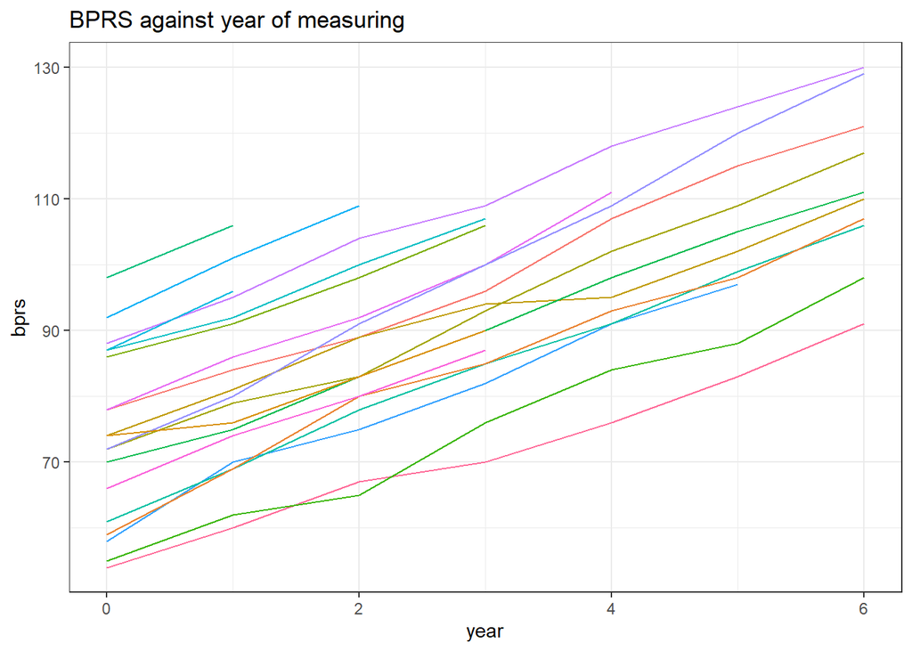

```r
ggplot(alz_rist1_long, aes(x = year, y = bprs, group = patid,
                                color = sample, show.legend = FALSE)) +
  geom_line(alpha = 1, show.legend = FALSE) +
  theme_bw() +
  labs(title = "BPRS against year of measuring")
```

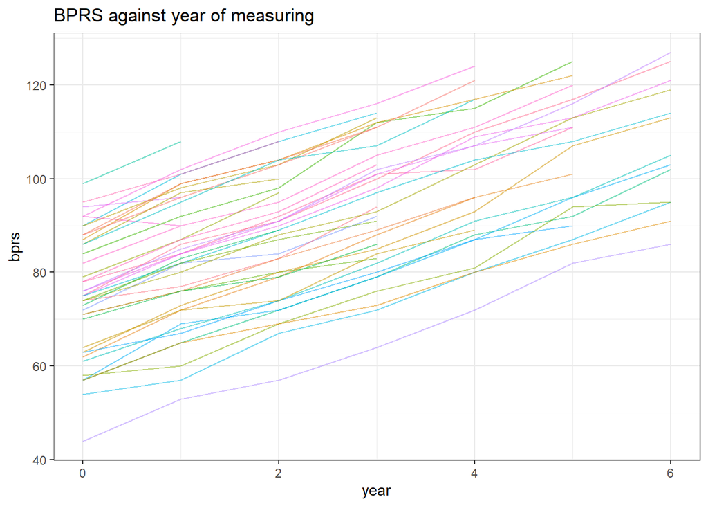

```r
ggplot(alz_rist_long, aes(x = year, y = bprs, group = patid,
                                color = sample, show.legend = FALSE)) +
  geom_line(alpha = 0.5, show.legend = FALSE) +
  theme_bw() +
  labs(title = "BPRS against year of measuring")
```

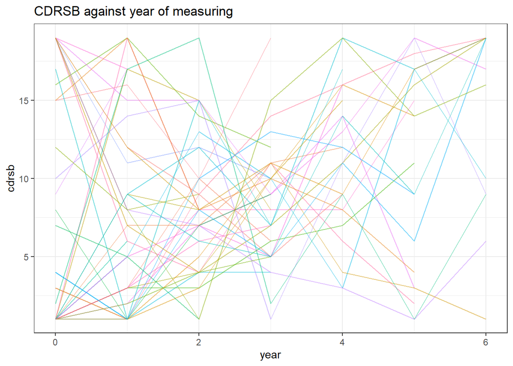

```r
ggplot(alz_rist_long, aes(x = year, y = cdrsb, group = patid,
                                color = sample, show.legend = FALSE)) +
  geom_line(alpha = 0.5, show.legend = FALSE) +
  theme_bw() +
  labs(title = "CDRSB against year of measuring")
```

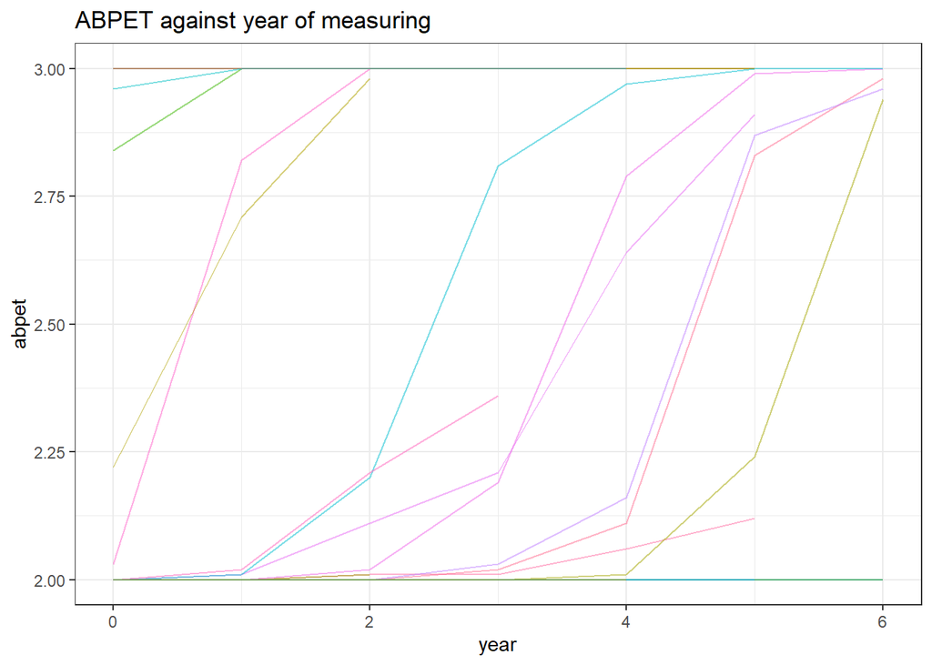

```r
ggplot(alz_rist_long, aes(x = year, y = abpet, group = patid,
                                color = sample, show.legend = FALSE)) +
  geom_line(alpha = 0.5, show.legend = FALSE) +
  theme_bw() +
  labs(title = "ABPET against year of measuring")
```

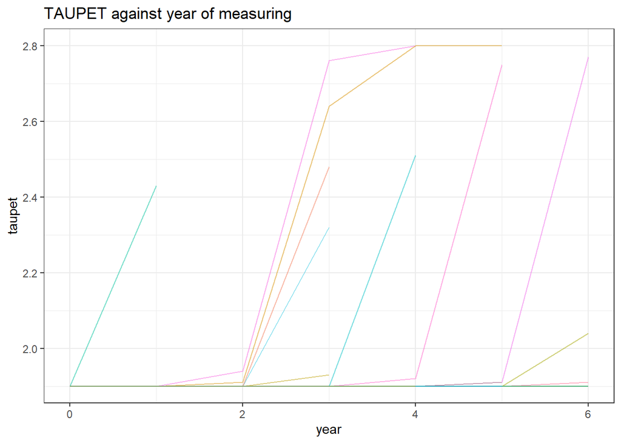

```r
ggplot(alz_rist_long, aes(x = year, y = taupet, group = patid,
                          color = sample, show.legend = FALSE)) +
  geom_line(alpha = 0.5, show.legend = FALSE) +
  theme_bw() +
  labs(title = "TAUPET against year of measuring")
```

Maybe we should analyze how many missing data we have??

Now try to estimate average behavior in different groups.

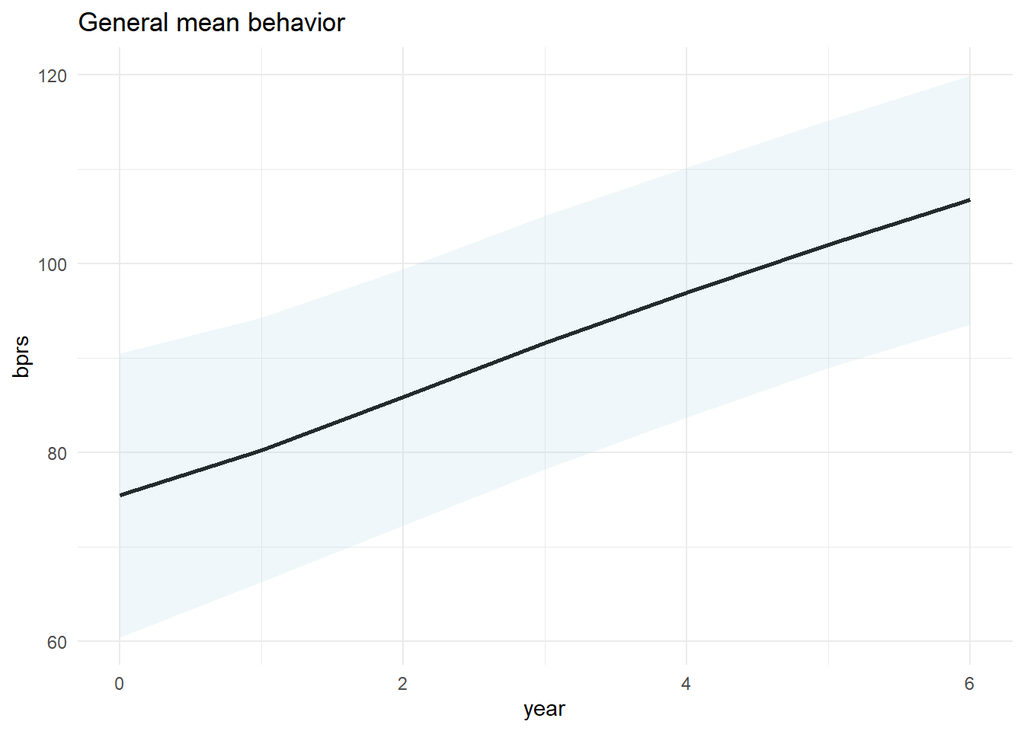

```r
## General behavior
ggplot(alz_long, aes(x = year, y = bprs)) +
  stat_summary(fun = mean, geom = "line", size = 1) +
  stat_summary(fun.data = mean_sdl, geom = "ribbon", fun.args = list(mult = 1),
               alpha = 0.2, fill = "lightblue") +
  theme_minimal() +
  labs(title = "General mean behavior")
```

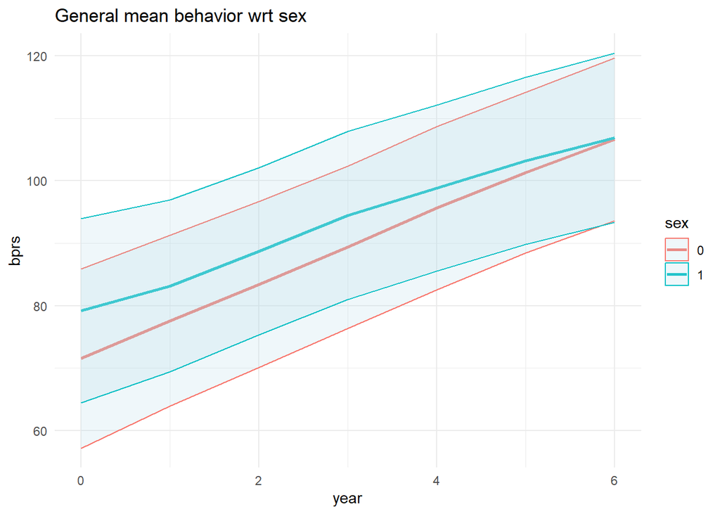

```r
ggplot(alz_long, aes(x = year, y = bprs, group = sex, color = sex)) +
  stat_summary(fun = mean, geom = "line", size = 1) +
  stat_summary(fun.data = mean_sdl, geom = "ribbon", fun.args = list(mult = 1),
               alpha = 0.2, fill = "lightblue") +
  theme_minimal() +
  labs(title = "General mean behavior wrt sex")
```

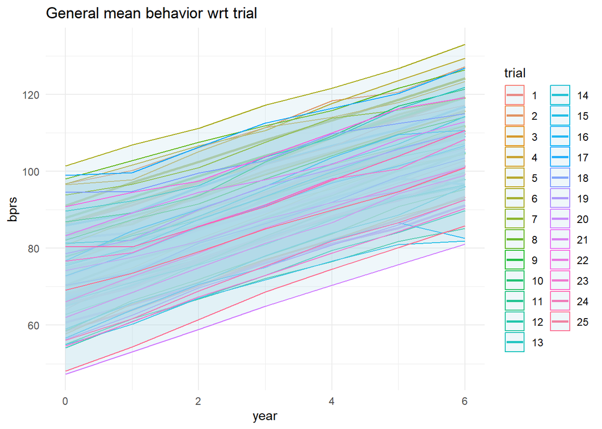

```r
ggplot(alz_long, aes(x = year, y = bprs, group = trial, color = trial)) +
  stat_summary(fun = mean, geom = "line", size = 1) +
  stat_summary(fun.data = mean_sdl, geom = "ribbon", fun.args = list(mult = 1),
               alpha = 0.2, fill = "lightblue") +
  theme_minimal() +
  labs(title = "General mean behavior wrt trial")
```

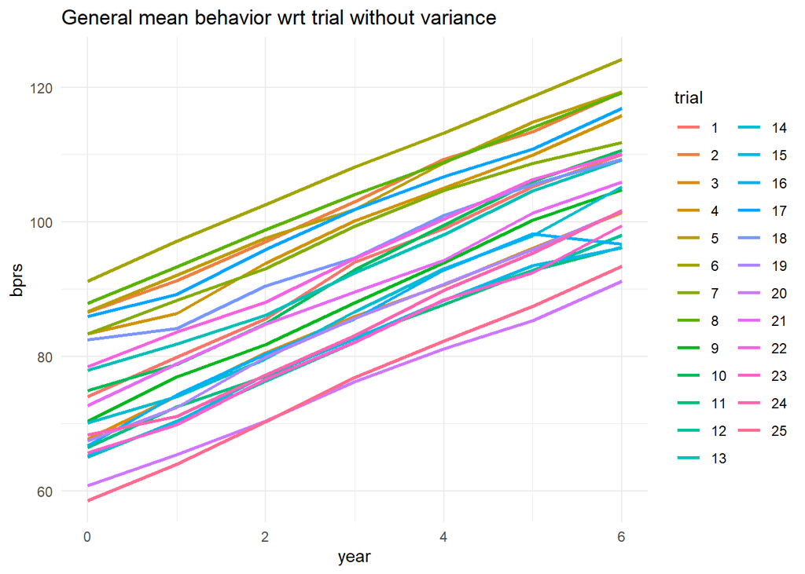

```r
ggplot(alz_long, aes(x = year, y = bprs, group = trial, color = trial)) +
  stat_summary(fun = mean, geom = "line", size = 1) +
  #stat_summary(fun.data = mean_sdl, geom = "ribbon", fun.args = list(mult = 1),
  #             alpha = 0.2, fill = "lightblue") +
  theme_minimal() +
  labs(title = "General mean behavior wrt trial without variance")
```

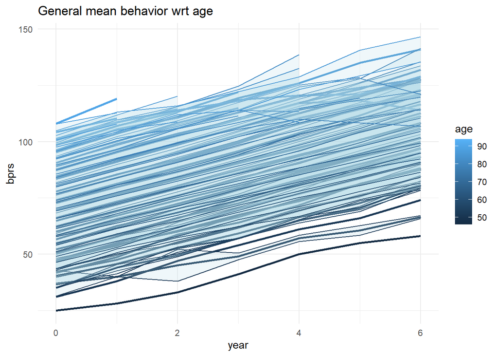

```r
ggplot(alz_long, aes(x = year, y = bprs, group = age, color = age)) +
  stat_summary(fun = mean, geom = "line", size = 1) +
  stat_summary(fun.data = mean_sdl, geom = "ribbon", fun.args = list(mult = 1),
               alpha = 0.2, fill = "lightblue") +
  theme_minimal() +
  labs(title = "General mean behavior wrt age")
```

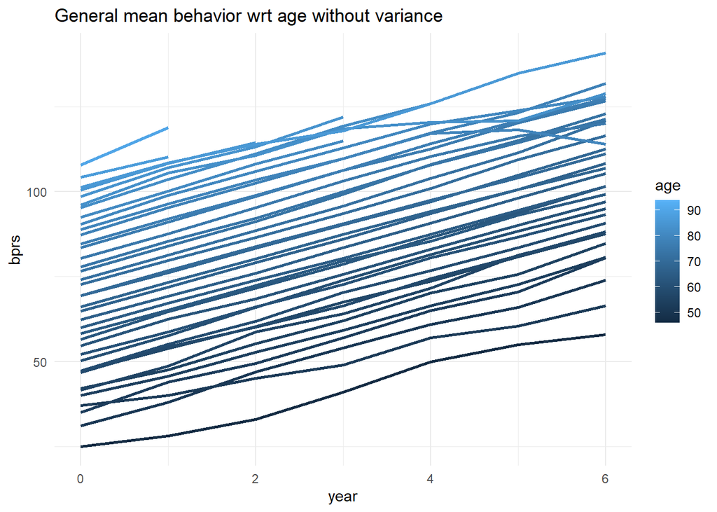

```r
ggplot(alz_long, aes(x = year, y = bprs, group = age, color = age)) +
  stat_summary(fun = mean, geom = "line", size = 1) +
  #stat_summary(fun.data = mean_sdl, geom = "ribbon", fun.args = list(mult = 1),
  #             alpha = 0.2, fill = "lightblue") +
  theme_minimal() +
  labs(title = "General mean behavior wrt age without variance")
```

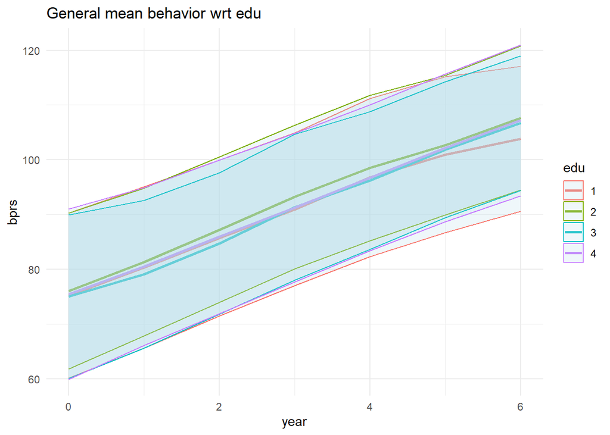

```r
ggplot(alz_long, aes(x = year, y = bprs, group = edu, color = edu)) +
  stat_summary(fun = mean, geom = "line", size = 1) +
  stat_summary(fun.data = mean_sdl, geom = "ribbon", fun.args = list(mult = 1),
               alpha = 0.2, fill = "lightblue") +
  theme_minimal() +
  labs(title = "General mean behavior wrt edu")
```

[output not shown]

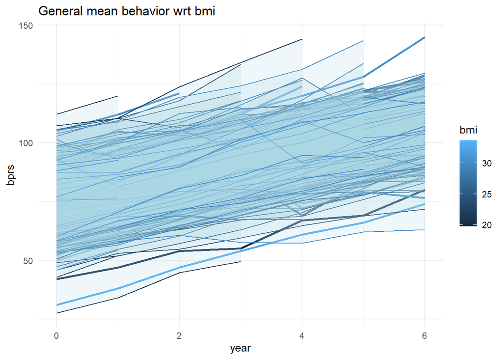

```r
ggplot(alz_long, aes(x = year, y = bprs, group = bmi, color = bmi)) +
  stat_summary(fun = mean, geom = "line", size = 1) +
  stat_summary(fun.data = mean_sdl, geom = "ribbon", fun.args = list(mult = 1),
               alpha = 0.2, fill = "lightblue") +
  theme_minimal() +
  labs(title = "General mean behavior wrt bmi")
```

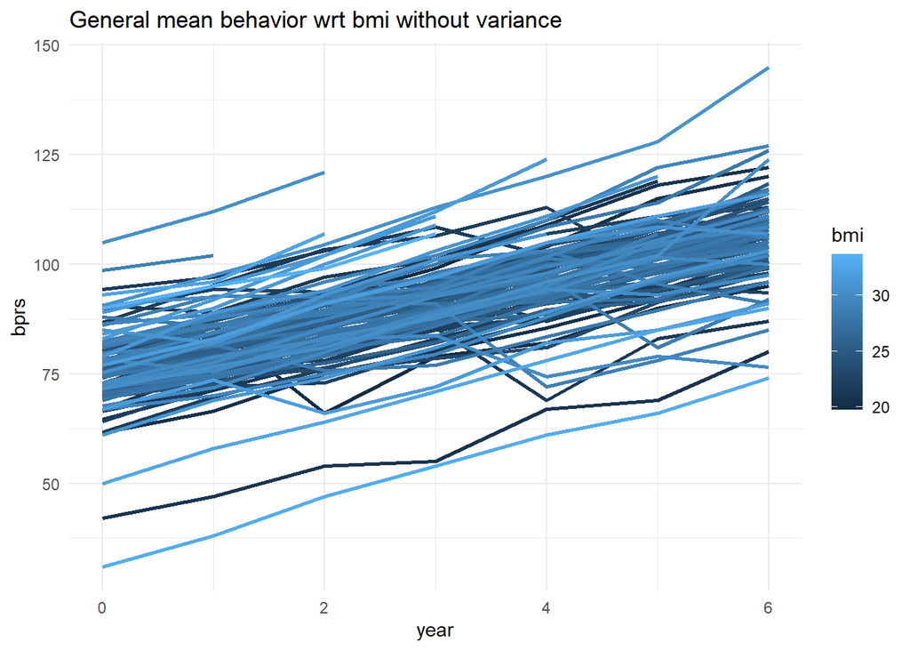

```r
ggplot(alz_long, aes(x = year, y = bprs, group = bmi, color = bmi)) +
  stat_summary(fun = mean, geom = "line", size = 1) +
  #stat_summary(fun.data = mean_sdl, geom = "ribbon", fun.args = list(mult = 1),
  #             alpha = 0.2, fill = "lightblue") +
  theme_minimal() +
  labs(title = "General mean behavior wrt bmi without variance")
```

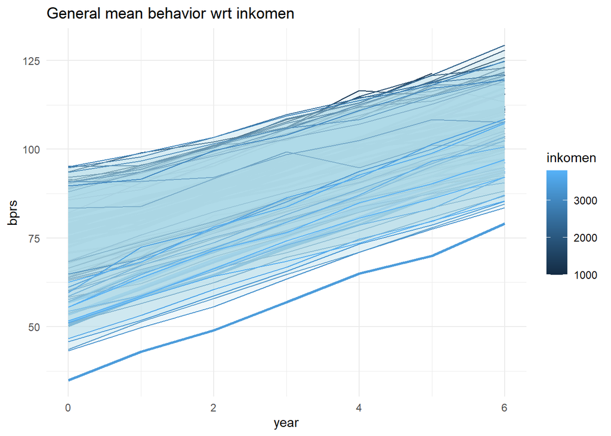

```r
ggplot(alz_long, aes(x = year, y = bprs, group = inkomen, color = inkomen)) +
  stat_summary(fun = mean, geom = "line", size = 1) +
  stat_summary(fun.data = mean_sdl, geom = "ribbon", fun.args = list(mult = 1),
               alpha = 0.2, fill = "lightblue") +
  theme_minimal() +
  labs(title = "General mean behavior wrt inkomen")
```

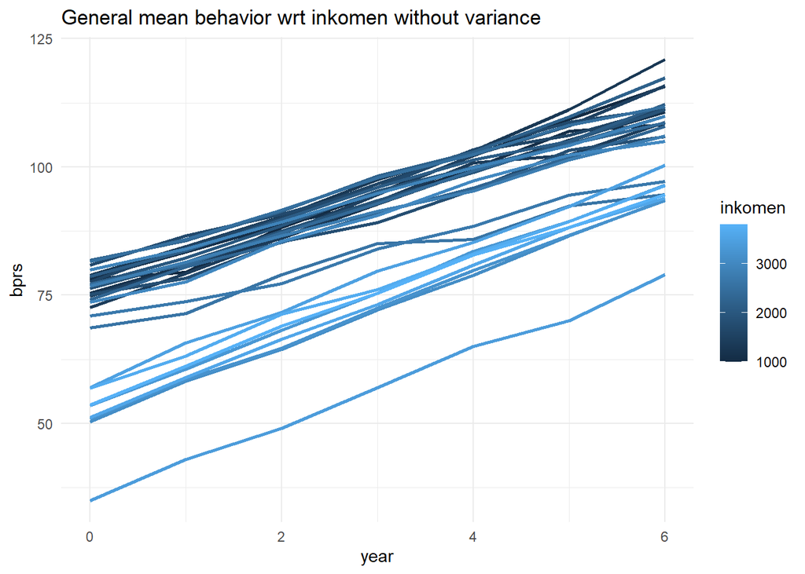

```r
ggplot(alz_long, aes(x = year, y = bprs, group = inkomen, color = inkomen)) +
  stat_summary(fun = mean, geom = "line", size = 1) +
  #stat_summary(fun.data = mean_sdl, geom = "ribbon", fun.args = list(mult = 1),
  #             alpha = 0.2, fill = "lightblue") +
  theme_minimal() +
  labs(title = "General mean behavior wrt inkomen without variance")
```

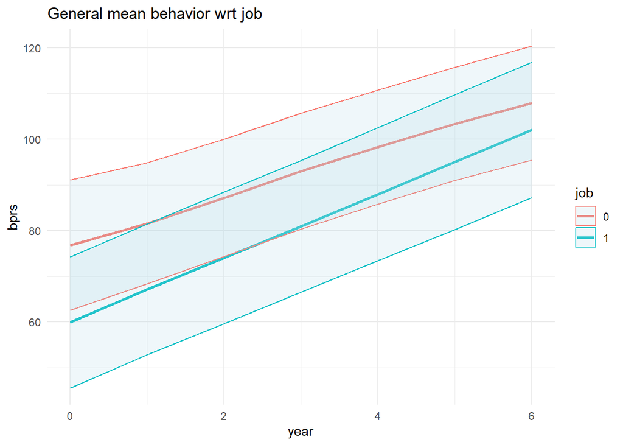

```r
ggplot(alz_long, aes(x = year, y = bprs, group = job, color = job)) +
  stat_summary(fun = mean, geom = "line", size = 1) +
  stat_summary(fun.data = mean_sdl, geom = "ribbon", fun.args = list(mult = 1),
               alpha = 0.2, fill = "lightblue") +
  theme_minimal() +
  labs(title = "General mean behavior wrt job")
```

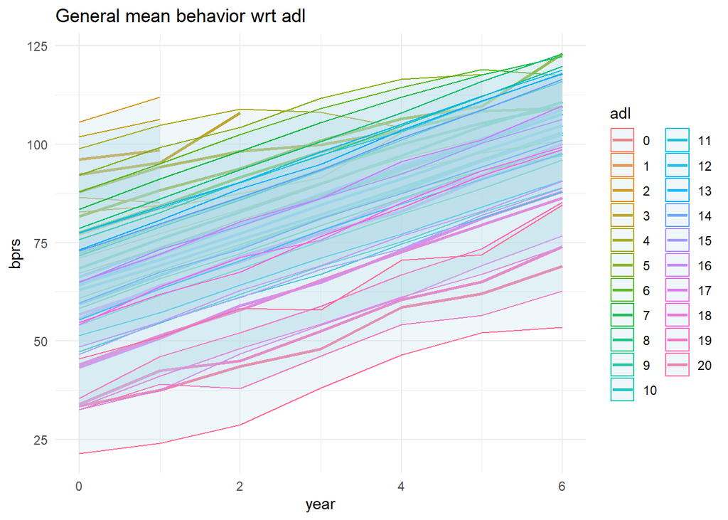

```r
ggplot(alz_long, aes(x = year, y = bprs, group = adl, color = adl)) +
  stat_summary(fun = mean, geom = "line", size = 1) +
  stat_summary(fun.data = mean_sdl, geom = "ribbon", fun.args = list(mult = 1),
               alpha = 0.2, fill = "lightblue") +
  theme_minimal() +
  labs(title = "General mean behavior wrt adl")
```

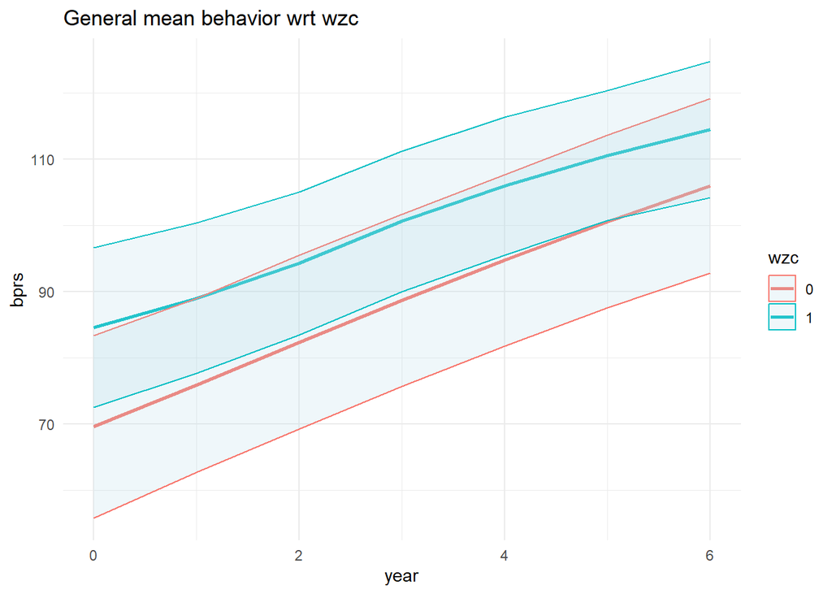

```r
ggplot(alz_long, aes(x = year, y = bprs, group = wzc, color = wzc)) +
  stat_summary(fun = mean, geom = "line", size = 1) +
  stat_summary(fun.data = mean_sdl, geom = "ribbon", fun.args = list(mult = 1),
               alpha = 0.2, fill = "lightblue") +
  theme_minimal() +
  labs(title = "General mean behavior wrt wzc")
```

*NOTA PERSONALE: con questo codice ggplot mostra una stima puntuale della deviazione standard, non della varianza, ma penso vada comunque bene? Prova a chiedere agli altri nel caso si sistema subito*

From the general mean behavior it seems that over the years the bprs value increases in a linear way. In addition it seems that the estimated variance among the years is more or less constant (so we can apply the variogram procedure??).

Speaking of the categorical variables, it seems to me that there are significant differences between groups speaking of sex (but not particularly marked), job and wzc. The variable edu seems to be not of particular interest?

Now we also have a look at the biological indicators (but maybe we will discretize them later on which is more significant).

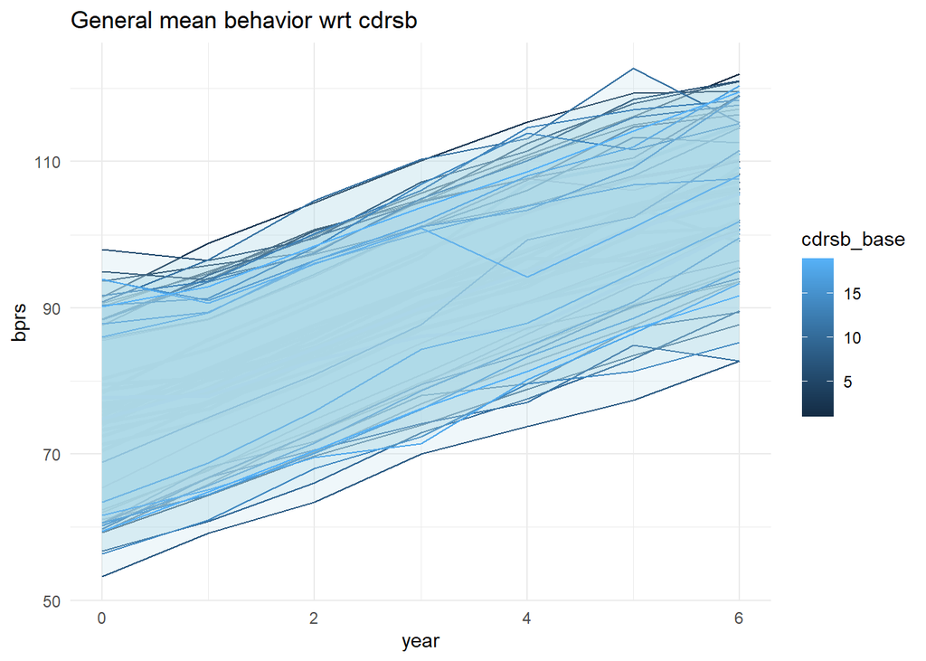

```r
ggplot(alz_long, aes(x = year, y = bprs, group = cdrsb_base, color = cdrsb_base)) +
  stat_summary(fun = mean, geom = "line", size = 1) +
  stat_summary(fun.data = mean_sdl, geom = "ribbon", fun.args = list(mult = 1),
               alpha = 0.2, fill = "lightblue") +
  theme_minimal() +
  labs(title = "General mean behavior wrt cdrsb")
```

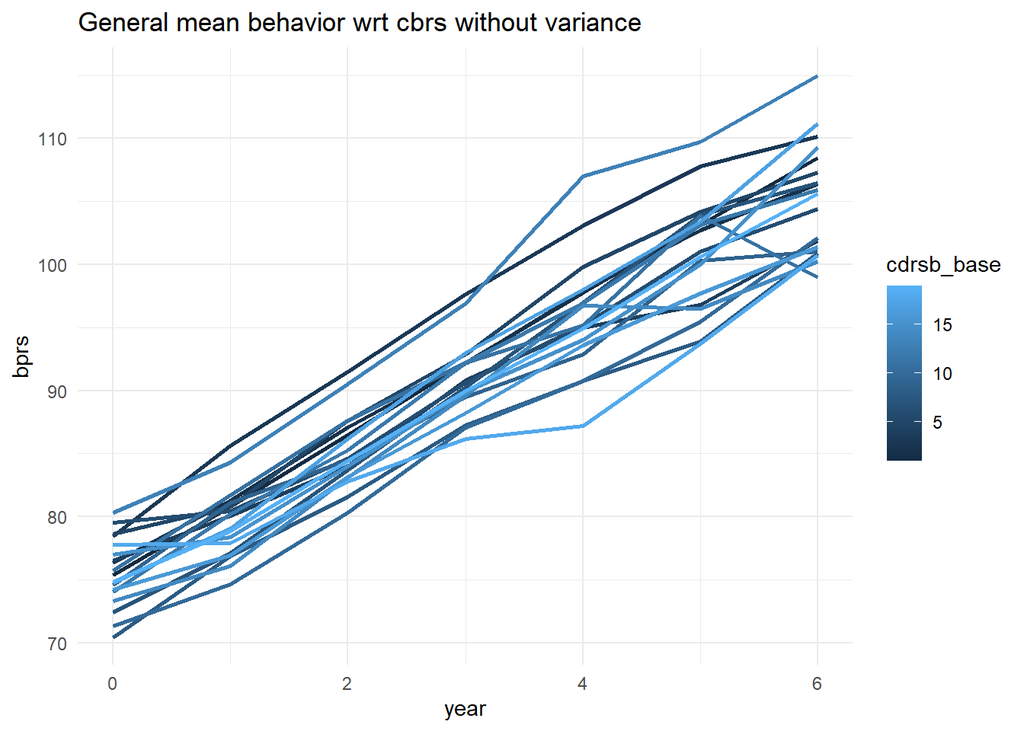

```r
ggplot(alz_long, aes(x = year, y = bprs, group = cdrsb_base, color = cdrsb_base)) +
  stat_summary(fun = mean, geom = "line", size = 1) +
  #stat_summary(fun.data = mean_sdl, geom = "ribbon", fun.args = list(mult = 1),
  #             alpha = 0.2, fill = "lightblue") +
  theme_minimal() +
  labs(title = "General mean behavior wrt cbrs without variance")
```

[output not shown]

[output cut: 9 more lines]

[output not shown]

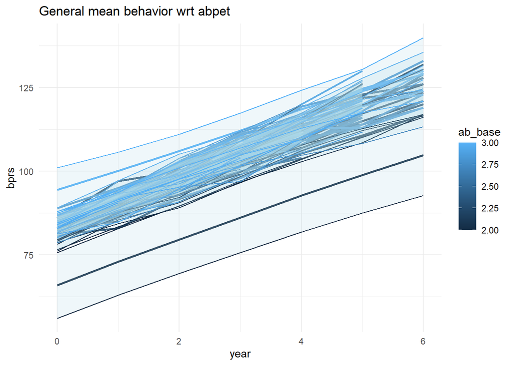

```r
ggplot(alz_long, aes(x = year, y = bprs, group = ab_base, color = ab_base)) +
  stat_summary(fun = mean, geom = "line", size = 1) +
  stat_summary(fun.data = mean_sdl, geom = "ribbon", fun.args = list(mult = 1),
               alpha = 0.2, fill = "lightblue") +
  theme_minimal() +
  labs(title = "General mean behavior wrt abpet")
```

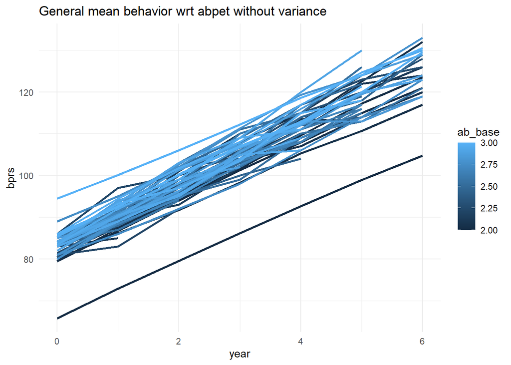

```r
ggplot(alz_long, aes(x = year, y = bprs, group = ab_base, color = ab_base)) +
  stat_summary(fun = mean, geom = "line", size = 1) +
  #stat_summary(fun.data = mean_sdl, geom = "ribbon", fun.args = list(mult = 1),
  #             alpha = 0.2, fill = "lightblue") +
  theme_minimal() +
  labs(title = "General mean behavior wrt abpet without variance")
```

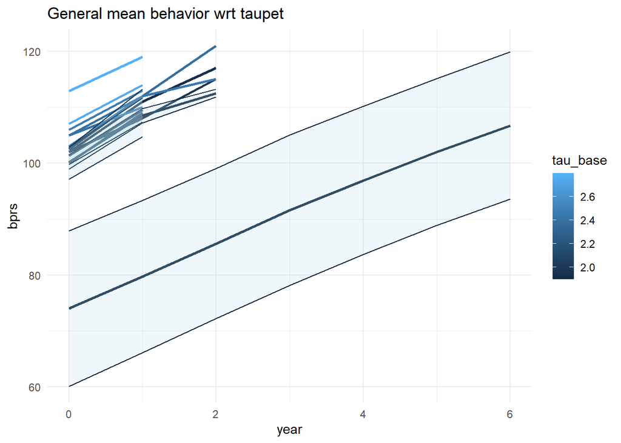

```r
ggplot(alz_long, aes(x = year, y = bprs, group = tau_base, color = tau_base)) +
  stat_summary(fun = mean, geom = "line", size = 1) +
  stat_summary(fun.data = mean_sdl, geom = "ribbon", fun.args = list(mult = 1),
               alpha = 0.2, fill = "lightblue") +
  theme_minimal() +
  labs(title = "General mean behavior wrt taupet")
```

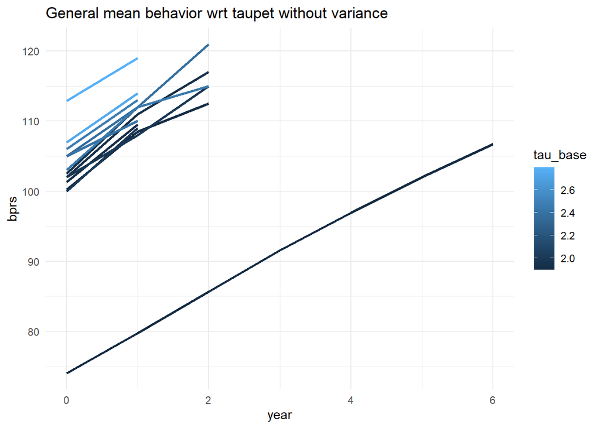

```r
ggplot(alz_long, aes(x = year, y = bprs, group = tau_base, color = tau_base)) +
  stat_summary(fun = mean, geom = "line", size = 1) +
  #stat_summary(fun.data = mean_sdl, geom = "ribbon", fun.args = list(mult = 1),
  #             alpha = 0.2, fill = "lightblue") +
  theme_minimal() +
  labs(title = "General mean behavior wrt taupet without variance")
```

Not that understandable.

Maybe we should discretize the continuous variables inside bins to see if there are significant differences. Should we consider the trial??

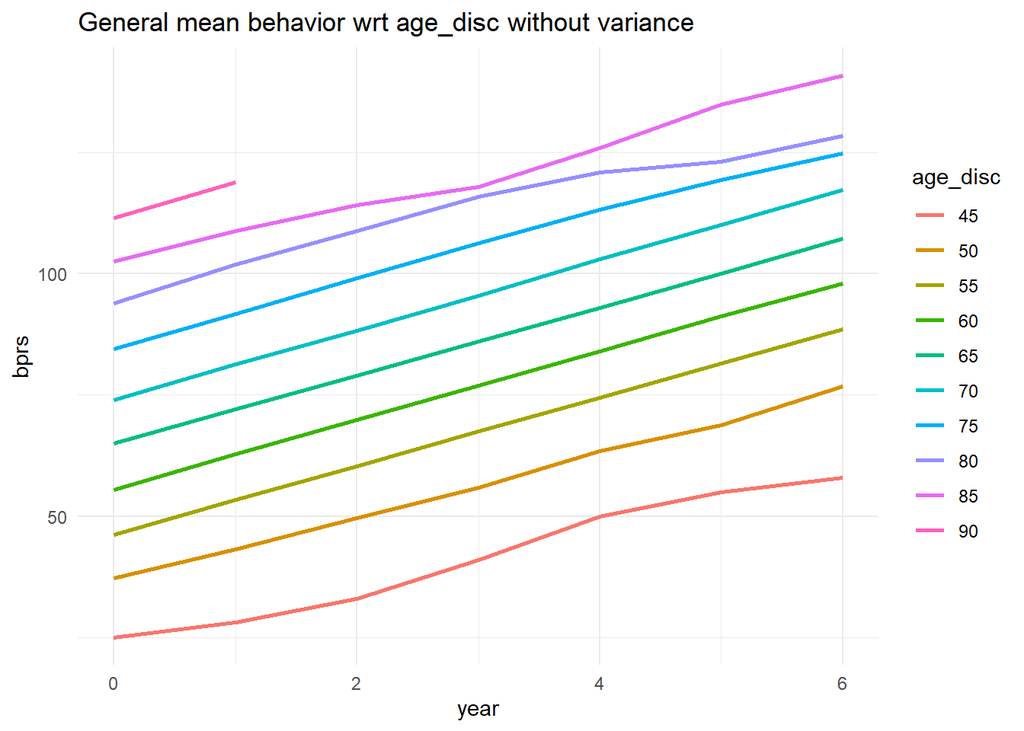

```r
ggplot(alz_long, aes(x = year, y = bprs, group = age_disc, color = age_disc)) +
  stat_summary(fun = mean, geom = "line", size = 1) +
  #stat_summary(fun.data = mean_sdl, geom = "ribbon", fun.args = list(mult = 1),
  #             alpha = 0.2, fill = "lightblue") +
  theme_minimal() +
  labs(title = "General mean behavior wrt age_disc without variance")
```

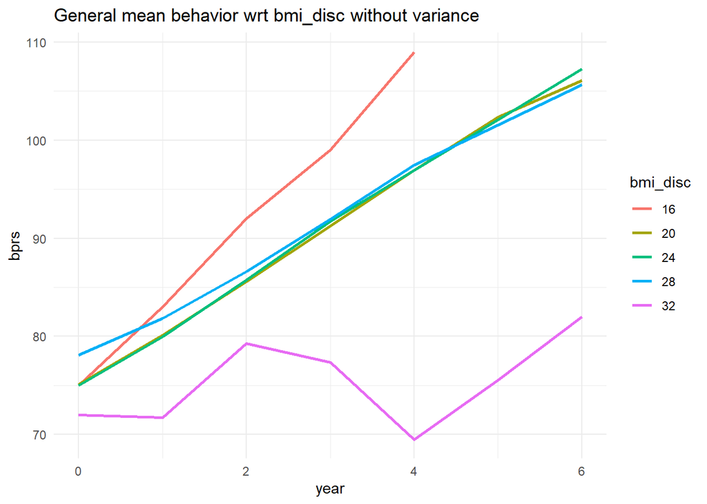

```r
ggplot(alz_long, aes(x = year, y = bprs, group = bmi_disc, color = bmi_disc)) +
  stat_summary(fun = mean, geom = "line", size = 1) +
  #stat_summary(fun.data = mean_sdl, geom = "ribbon", fun.args = list(mult = 1),
  #             alpha = 0.2, fill = "lightblue") +
  theme_minimal() +
  labs(title = "General mean behavior wrt bmi_disc without variance")
```

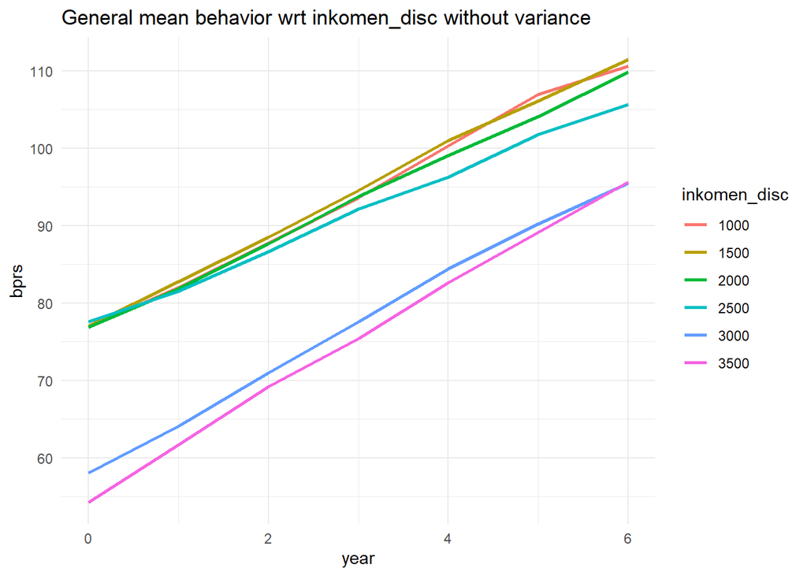

```r
ggplot(alz_long, aes(x = year, y = bprs, group = inkomen_disc, color = inkomen_disc)) +
  stat_summary(fun = mean, geom = "line", size = 1) +
  #stat_summary(fun.data = mean_sdl, geom = "ribbon", fun.args = list(mult = 1),
  #             alpha = 0.2, fill = "lightblue") +
  theme_minimal() +
  labs(title = "General mean behavior wrt inkomen_disc without variance")
```

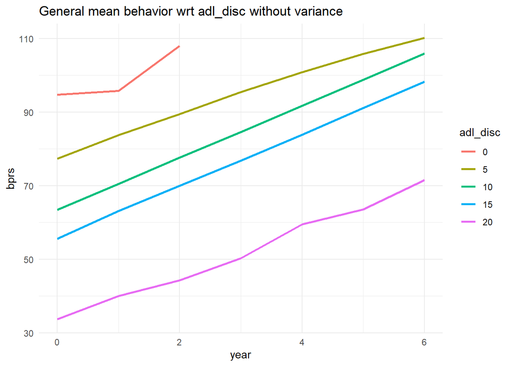

```r
ggplot(alz_long, aes(x = year, y = bprs, group = adl_disc, color = adl_disc)) +
  stat_summary(fun = mean, geom = "line", size = 1) +
  #stat_summary(fun.data = mean_sdl, geom = "ribbon", fun.args = list(mult = 1),
  #             alpha = 0.2, fill = "lightblue") +
  theme_minimal() +
  labs(title = "General mean behavior wrt adl_disc without variance")
```

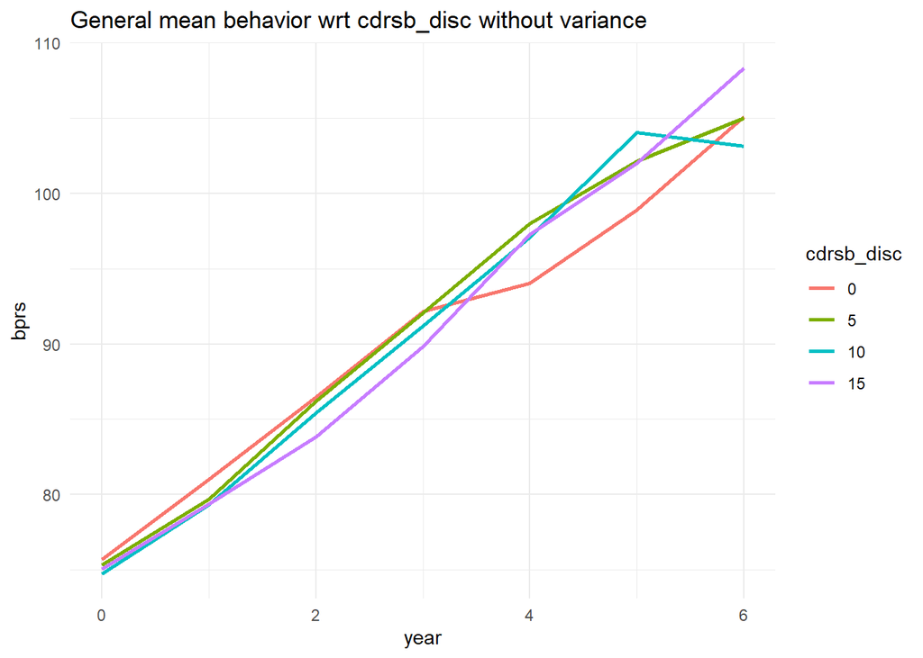

```r
ggplot(alz_long, aes(x = year, y = bprs, group = cdrsb_disc, color = cdrsb_disc)) +
  stat_summary(fun = mean, geom = "line", size = 1) +
  #stat_summary(fun.data = mean_sdl, geom = "ribbon", fun.args = list(mult = 1),
  #             alpha = 0.2, fill = "lightblue") +
  theme_minimal() +
  labs(title = "General mean behavior wrt cdrsb_disc without variance")
```

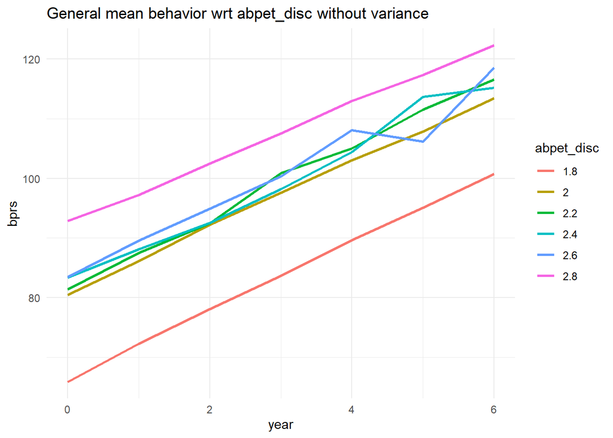

```r
ggplot(alz_long, aes(x = year, y = bprs, group = abpet_disc, color = abpet_disc)) +
  stat_summary(fun = mean, geom = "line", size = 1) +
  #stat_summary(fun.data = mean_sdl, geom = "ribbon", fun.args = list(mult = 1),
  #             alpha = 0.2, fill = "lightblue") +
  theme_minimal() +
  labs(title = "General mean behavior wrt abpet_disc without variance")
```

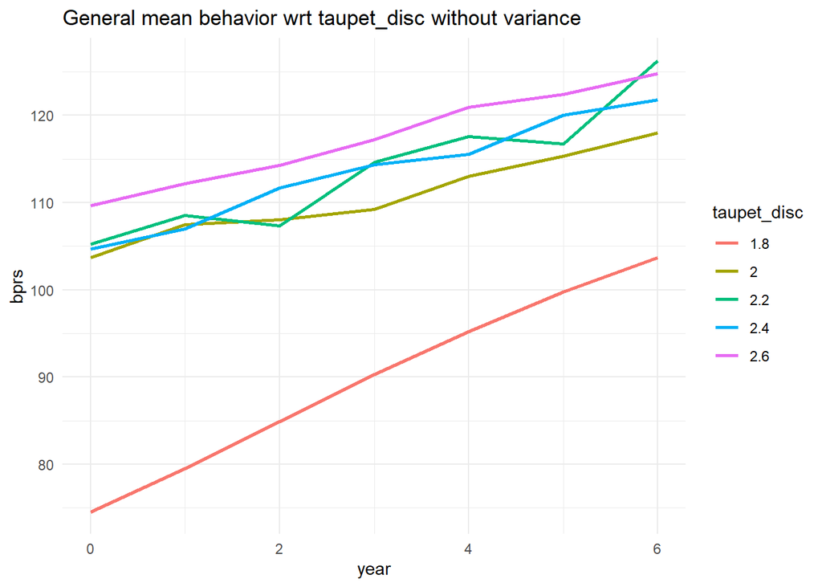

```r
ggplot(alz_long, aes(x = year, y = bprs, group = taupet_disc, color = taupet_disc)) +
  stat_summary(fun = mean, geom = "line", size = 1) +
  #stat_summary(fun.data = mean_sdl, geom = "ribbon", fun.args = list(mult = 1),
  #             alpha = 0.2, fill = "lightblue") +
  theme_minimal() +
  labs(title = "General mean behavior wrt taupet_disc without variance")
```